# Relatório dos dados de vendas da Amazon - Objetivo e Processamento dos Dados

Aluno: Pedro Henrique Batista Chitarra

Professor: Nilton Kazuyuki Ueda

# Descrição do Problema

Fonte dos dados: [Amazon Sales Dataset](https://www.kaggle.com/datasets/karkavelrajaj/amazon-sales-dataset)

A Amazon é responsável por uma quantidade enorme de vendas online e se tem informações sobre avaliações de diversos produtos em diferentes categorias.

O objetivo da análise é identificar produtos e categorias mais avaliados (portanto, provavelmente mais vendidos) e entender a relação entre desconto, preço e quantidade de vendas.

Essas perguntas ajudarão a entender melhor a performance de vendas relacionadas aos descontos. É importante entender se maiores descontos estão relacionados a maiores vendas, ou se produtos mais caros são mais bem avaliados.

Com essa informação extraída dos dados, a Amazon poderá tomar decisões mais assertivas sobre a estratégia de vendas, como por exemplo, aumentar o desconto de produtos com baixa avaliação, ou aumentar o preço de produtos bem avaliados.

# Descrição dos dados

## Colunas

- product_id - ID do Produto
- product_name - Nome do Produto
- category - Categoria do Produto
- discounted_price - Preço com Desconto do Produto
- actual_price - Preço Real do Produto
- discount_percentage - Porcentagem de Desconto do Produto
- rating - Avaliação do Produto
- rating_count - Quantidade de Avaliações do Produto
- about_product - Descrição do Produto
- user_id - ID do Usuário que escreveu a avaliação
- user_name - Nome do Usuário que escreveu a avaliação
- review_id - ID da Avaliação
- review_title - Título da Avaliação
- review_content - Conteúdo da Avaliação
- img_link - Link da Imagem do Produto
- product_link - Link do Produto

# Visão geral dos dados

## Importando as bibliotecas

```python
import pandas as pd
import plotly.graph_objects as go
import numpy as np
```

## Carregando os dados

```python
df = pd.read_csv("amazon.csv")
df.head()
```

|  | product_id | product_name | category | discounted_price | actual_price | discount_percentage | rating | rating_count | about_product | user_id | user_name | review_id | review_title | review_content | img_link | product_link |
| --- | --- | --- | --- | --- | --- | --- | --- | --- | --- | --- | --- | --- | --- | --- | --- | --- |
| 0 | B07JW9H4J1 | Wayona Nylon Braided USB to Lightning Fast Cha... | Computers&Accessories\|Accessories&Peripherals\|... | ₹399 | ₹1,099 | 64% | 4.2 | 24,269 | High Compatibility : Compatible With iPhone 12... | AG3D6O4STAQKAY2UVGEUV46KN35Q,AHMY5CWJMMK5BJRBB... | Manav,Adarsh gupta,Sundeep,S.Sayeed Ahmed,jasp... | R3HXWT0LRP0NMF,R2AJM3LFTLZHFO,R6AQJGUP6P86,R1K... | Satisfied,Charging is really fast,Value for mo... | Looks durable Charging is fine tooNo complains... | https://m.media-amazon.com/images/W/WEBP_40237... | https://www.amazon.in/Wayona-Braided-WN3LG1-Sy... |
| 1 | B098NS6PVG | Ambrane Unbreakable 60W / 3A Fast Charging 1.5... | Computers&Accessories\|Accessories&Peripherals\|... | ₹199 | ₹349 | 43% | 4.0 | 43,994 | Compatible with all Type C enabled devices, be... | AECPFYFQVRUWC3KGNLJIOREFP5LQ,AGYYVPDD7YG7FYNBX... | ArdKn,Nirbhay kumar,Sagar Viswanathan,Asp,Plac... | RGIQEG07R9HS2,R1SMWZQ86XIN8U,R2J3Y1WL29GWDE,RY... | A Good Braided Cable for Your Type C Device,Go... | I ordered this cable to connect my phone to An... | https://m.media-amazon.com/images/W/WEBP_40237... | https://www.amazon.in/Ambrane-Unbreakable-Char... |
| 2 | B096MSW6CT | Sounce Fast Phone Charging Cable & Data Sync U... | Computers&Accessories\|Accessories&Peripherals\|... | ₹199 | ₹1,899 | 90% | 3.9 | 7,928 | 【 Fast Charger& Data Sync】-With built-in safet... | AGU3BBQ2V2DDAMOAKGFAWDDQ6QHA,AESFLDV2PT363T2AQ... | Kunal,Himanshu,viswanath,sai niharka,saqib mal... | R3J3EQQ9TZI5ZJ,R3E7WBGK7ID0KV,RWU79XKQ6I1QF,R2... | Good speed for earlier versions,Good Product,W... | Not quite durable and sturdy,https://m.media-a... | https://m.media-amazon.com/images/W/WEBP_40237... | https://www.amazon.in/Sounce-iPhone-Charging-C... |
| 3 | B08HDJ86NZ | boAt Deuce USB 300 2 in 1 Type-C & Micro USB S... | Computers&Accessories\|Accessories&Peripherals\|... | ₹329 | ₹699 | 53% | 4.2 | 94,363 | The boAt Deuce USB 300 2 in 1 cable is compati... | AEWAZDZZJLQUYVOVGBEUKSLXHQ5A,AG5HTSFRRE6NL3M5S... | Omkar dhale,JD,HEMALATHA,Ajwadh a.,amar singh ... | R3EEUZKKK9J36I,R3HJVYCLYOY554,REDECAZ7AMPQC,R1... | Good product,Good one,Nice,Really nice product... | Good product,long wire,Charges good,Nice,I bou... | https://m.media-amazon.com/images/I/41V5FtEWPk... | https://www.amazon.in/Deuce-300-Resistant-Tang... |
| 4 | B08CF3B7N1 | Portronics Konnect L 1.2M Fast Charging 3A 8 P... | Computers&Accessories\|Accessories&Peripherals\|... | ₹154 | ₹399 | 61% | 4.2 | 16,905 | [CHARGE & SYNC FUNCTION]- This cable comes wit... | AE3Q6KSUK5P75D5HFYHCRAOLODSA,AFUGIFH5ZAFXRDSZH... | rahuls6099,Swasat Borah,Ajay Wadke,Pranali,RVK... | R1BP4L2HH9TFUP,R16PVJEXKV6QZS,R2UPDB81N66T4P,R... | As good as original,Decent,Good one for second... | Bought this instead of original apple, does th... | https://m.media-amazon.com/images/W/WEBP_40237... | https://www.amazon.in/Portronics-Konnect-POR-1... |

## Informações sobre os dados

```python
df.info()
```

```
<class 'pandas.core.frame.DataFrame'>
RangeIndex: 1465 entries, 0 to 1464
Data columns (total 16 columns):
 #   Column               Non-Null Count  Dtype
---  ------               --------------  -----
 0   product_id           1465 non-null   object
 1   product_name         1465 non-null   object
 2   category             1465 non-null   object
 3   discounted_price     1465 non-null   object
 4   actual_price         1465 non-null   object
 5   discount_percentage  1465 non-null   object
 6   rating               1465 non-null   object
 7   rating_count         1463 non-null   object
 8   about_product        1465 non-null   object
 9   user_id              1465 non-null   object
 10  user_name            1465 non-null   object
 11  review_id            1465 non-null   object
 12  review_title         1465 non-null   object
 13  review_content       1465 non-null   object
 14  img_link             1465 non-null   object
 15  product_link         1465 non-null   object
dtypes: object(16)
memory usage: 183.2+ KB
```

## Processamento dos dados

### Dados duplicados

```python
df["product_id"].duplicated().sum()
```

```
114
```

Tem 114 produtos duplicados no dataset ao se observar a coluna product_id, que era esperado ser único. Por isso, esses dados duplicados serão removidos e a primeira ocorrência será mantida.

```python
df = df.drop_duplicates("product_id")
```

### Dados faltantes

Dois produtos não têm contagem de avaliação, então esses produtos serão removidos da análise.

```python
df.isna().sum()
```

```
product_id             0
product_name           0
category               0
discounted_price       0
actual_price           0
discount_percentage    0
rating                 0
rating_count           2
about_product          0
user_id                0
user_name              0
review_id              0
review_title           0
review_content         0
img_link               0
product_link           0
dtype: int64
```

```python
df = df.dropna(subset=["rating_count"])
```

### Moeda

Os valores estão em Rúpias Indianas (₹), então será feita a conversão para dólares americanos (USD) para facilitar a compreensão dos valores. No dia 01/10/2024, a rúpia indiana estava cotada a 0.012 USD, então será utilizada essa cotação para a conversão.

```python
df["discounted_price"] = df["discounted_price"].str.replace(
    "₹", "").str.replace(",", "").astype(float)
df["actual_price"] = df["actual_price"].str.replace(
    "₹", "").str.replace(",", "").astype(float)
```

```python
df["discounted_price"] = df["discounted_price"]*0.012
df["actual_price"] = df["actual_price"]*0.012
```

### Porcentagem de desconto

Os valores de desconto estão em porcentagem em forma de texto, então será feita a conversão para valores numéricos.

```python
df["discount_percentage"] = df[
    "discount_percentage"].str.replace("%", "").astype(float)
```

Verificando o resultado das transformações

```python
df.head()
```

|  | product_id | product_name | category | discounted_price | actual_price | discount_percentage | rating | rating_count | about_product | user_id | user_name | review_id | review_title | review_content | img_link | product_link |
| --- | --- | --- | --- | --- | --- | --- | --- | --- | --- | --- | --- | --- | --- | --- | --- | --- |
| 0 | B07JW9H4J1 | Wayona Nylon Braided USB to Lightning Fast Cha... | Computers&Accessories\|Accessories&Peripherals\|... | 4.788 | 13.188 | 64.0 | 4.2 | 24,269 | High Compatibility : Compatible With iPhone 12... | AG3D6O4STAQKAY2UVGEUV46KN35Q,AHMY5CWJMMK5BJRBB... | Manav,Adarsh gupta,Sundeep,S.Sayeed Ahmed,jasp... | R3HXWT0LRP0NMF,R2AJM3LFTLZHFO,R6AQJGUP6P86,R1K... | Satisfied,Charging is really fast,Value for mo... | Looks durable Charging is fine tooNo complains... | https://m.media-amazon.com/images/W/WEBP_40237... | https://www.amazon.in/Wayona-Braided-WN3LG1-Sy... |
| 1 | B098NS6PVG | Ambrane Unbreakable 60W / 3A Fast Charging 1.5... | Computers&Accessories\|Accessories&Peripherals\|... | 2.388 | 4.188 | 43.0 | 4.0 | 43,994 | Compatible with all Type C enabled devices, be... | AECPFYFQVRUWC3KGNLJIOREFP5LQ,AGYYVPDD7YG7FYNBX... | ArdKn,Nirbhay kumar,Sagar Viswanathan,Asp,Plac... | RGIQEG07R9HS2,R1SMWZQ86XIN8U,R2J3Y1WL29GWDE,RY... | A Good Braided Cable for Your Type C Device,Go... | I ordered this cable to connect my phone to An... | https://m.media-amazon.com/images/W/WEBP_40237... | https://www.amazon.in/Ambrane-Unbreakable-Char... |
| 2 | B096MSW6CT | Sounce Fast Phone Charging Cable & Data Sync U... | Computers&Accessories\|Accessories&Peripherals\|... | 2.388 | 22.788 | 90.0 | 3.9 | 7,928 | 【 Fast Charger& Data Sync】-With built-in safet... | AGU3BBQ2V2DDAMOAKGFAWDDQ6QHA,AESFLDV2PT363T2AQ... | Kunal,Himanshu,viswanath,sai niharka,saqib mal... | R3J3EQQ9TZI5ZJ,R3E7WBGK7ID0KV,RWU79XKQ6I1QF,R2... | Good speed for earlier versions,Good Product,W... | Not quite durable and sturdy,https://m.media-a... | https://m.media-amazon.com/images/W/WEBP_40237... | https://www.amazon.in/Sounce-iPhone-Charging-C... |
| 3 | B08HDJ86NZ | boAt Deuce USB 300 2 in 1 Type-C & Micro USB S... | Computers&Accessories\|Accessories&Peripherals\|... | 3.948 | 8.388 | 53.0 | 4.2 | 94,363 | The boAt Deuce USB 300 2 in 1 cable is compati... | AEWAZDZZJLQUYVOVGBEUKSLXHQ5A,AG5HTSFRRE6NL3M5S... | Omkar dhale,JD,HEMALATHA,Ajwadh a.,amar singh ... | R3EEUZKKK9J36I,R3HJVYCLYOY554,REDECAZ7AMPQC,R1... | Good product,Good one,Nice,Really nice product... | Good product,long wire,Charges good,Nice,I bou... | https://m.media-amazon.com/images/I/41V5FtEWPk... | https://www.amazon.in/Deuce-300-Resistant-Tang... |
| 4 | B08CF3B7N1 | Portronics Konnect L 1.2M Fast Charging 3A 8 P... | Computers&Accessories\|Accessories&Peripherals\|... | 1.848 | 4.788 | 61.0 | 4.2 | 16,905 | [CHARGE & SYNC FUNCTION]- This cable comes wit... | AE3Q6KSUK5P75D5HFYHCRAOLODSA,AFUGIFH5ZAFXRDSZH... | rahuls6099,Swasat Borah,Ajay Wadke,Pranali,RVK... | R1BP4L2HH9TFUP,R16PVJEXKV6QZS,R2UPDB81N66T4P,R... | As good as original,Decent,Good one for second... | Bought this instead of original apple, does th... | https://m.media-amazon.com/images/W/WEBP_40237... | https://www.amazon.in/Portronics-Konnect-POR-1... |

Verificando o tipo dos dados

```python
df.dtypes
```

```
product_id              object
product_name            object
category                object
discounted_price       float64
actual_price           float64
discount_percentage    float64
rating                  object
rating_count            object
about_product           object
user_id                 object
user_name               object
review_id               object
review_title            object
review_content          object
img_link                object
product_link            object
dtype: object
```

As colunas rating, rating_count ainda estão como texto, então serão convertidas para valores numéricos.

**rating**

```python
df["rating"] = pd.to_numeric(df["rating"], errors="coerce")
```

```python
df["rating"].isna().sum()
```

```
1
```

Após conversão, um valor NA foi gerado e essa linha será removida.

```python
df = df.dropna(subset=["rating"])
```

**rating_count**

```python
df["rating_count"].value_counts()
```

```
9,378     9
18,998    8
24,269    6
32,840    5
19,252    5
         ..
5,176     1
8,614     1
60,026    1
3,066     1
6,987     1
Name: rating_count, Length: 1116, dtype: int64
```

Substituindo as vírgulas por pontos e convertendo para valores numéricos

```python
df["rating_count"] = df["rating_count"].str.replace(",", ".")
df["rating_count"]
```

```
0       24.269
1       43.994
2        7.928
3       94.363
4       16.905
         ...
1460     1.090
1461     4.118
1462       468
1463     8.031
1464     6.987
Name: rating_count, Length: 1348, dtype: object
```

```python
df["rating_count"] = pd.to_numeric(df["rating_count"], errors="coerce")
```

Verificando o resultado das transformações

```python
df.head()
```

|  | product_id | product_name | category | discounted_price | actual_price | discount_percentage | rating | rating_count | about_product | user_id | user_name | review_id | review_title | review_content | img_link | product_link |
| --- | --- | --- | --- | --- | --- | --- | --- | --- | --- | --- | --- | --- | --- | --- | --- | --- |
| 0 | B07JW9H4J1 | Wayona Nylon Braided USB to Lightning Fast Cha... | Computers&Accessories\|Accessories&Peripherals\|... | 4.788 | 13.188 | 64.0 | 4.2 | 24.269 | High Compatibility : Compatible With iPhone 12... | AG3D6O4STAQKAY2UVGEUV46KN35Q,AHMY5CWJMMK5BJRBB... | Manav,Adarsh gupta,Sundeep,S.Sayeed Ahmed,jasp... | R3HXWT0LRP0NMF,R2AJM3LFTLZHFO,R6AQJGUP6P86,R1K... | Satisfied,Charging is really fast,Value for mo... | Looks durable Charging is fine tooNo complains... | https://m.media-amazon.com/images/W/WEBP_40237... | https://www.amazon.in/Wayona-Braided-WN3LG1-Sy... |
| 1 | B098NS6PVG | Ambrane Unbreakable 60W / 3A Fast Charging 1.5... | Computers&Accessories\|Accessories&Peripherals\|... | 2.388 | 4.188 | 43.0 | 4.0 | 43.994 | Compatible with all Type C enabled devices, be... | AECPFYFQVRUWC3KGNLJIOREFP5LQ,AGYYVPDD7YG7FYNBX... | ArdKn,Nirbhay kumar,Sagar Viswanathan,Asp,Plac... | RGIQEG07R9HS2,R1SMWZQ86XIN8U,R2J3Y1WL29GWDE,RY... | A Good Braided Cable for Your Type C Device,Go... | I ordered this cable to connect my phone to An... | https://m.media-amazon.com/images/W/WEBP_40237... | https://www.amazon.in/Ambrane-Unbreakable-Char... |
| 2 | B096MSW6CT | Sounce Fast Phone Charging Cable & Data Sync U... | Computers&Accessories\|Accessories&Peripherals\|... | 2.388 | 22.788 | 90.0 | 3.9 | 7.928 | 【 Fast Charger& Data Sync】-With built-in safet... | AGU3BBQ2V2DDAMOAKGFAWDDQ6QHA,AESFLDV2PT363T2AQ... | Kunal,Himanshu,viswanath,sai niharka,saqib mal... | R3J3EQQ9TZI5ZJ,R3E7WBGK7ID0KV,RWU79XKQ6I1QF,R2... | Good speed for earlier versions,Good Product,W... | Not quite durable and sturdy,https://m.media-a... | https://m.media-amazon.com/images/W/WEBP_40237... | https://www.amazon.in/Sounce-iPhone-Charging-C... |
| 3 | B08HDJ86NZ | boAt Deuce USB 300 2 in 1 Type-C & Micro USB S... | Computers&Accessories\|Accessories&Peripherals\|... | 3.948 | 8.388 | 53.0 | 4.2 | 94.363 | The boAt Deuce USB 300 2 in 1 cable is compati... | AEWAZDZZJLQUYVOVGBEUKSLXHQ5A,AG5HTSFRRE6NL3M5S... | Omkar dhale,JD,HEMALATHA,Ajwadh a.,amar singh ... | R3EEUZKKK9J36I,R3HJVYCLYOY554,REDECAZ7AMPQC,R1... | Good product,Good one,Nice,Really nice product... | Good product,long wire,Charges good,Nice,I bou... | https://m.media-amazon.com/images/I/41V5FtEWPk... | https://www.amazon.in/Deuce-300-Resistant-Tang... |
| 4 | B08CF3B7N1 | Portronics Konnect L 1.2M Fast Charging 3A 8 P... | Computers&Accessories\|Accessories&Peripherals\|... | 1.848 | 4.788 | 61.0 | 4.2 | 16.905 | [CHARGE & SYNC FUNCTION]- This cable comes wit... | AE3Q6KSUK5P75D5HFYHCRAOLODSA,AFUGIFH5ZAFXRDSZH... | rahuls6099,Swasat Borah,Ajay Wadke,Pranali,RVK... | R1BP4L2HH9TFUP,R16PVJEXKV6QZS,R2UPDB81N66T4P,R... | As good as original,Decent,Good one for second... | Bought this instead of original apple, does th... | https://m.media-amazon.com/images/W/WEBP_40237... | https://www.amazon.in/Portronics-Konnect-POR-1... |

Verificando se ainda tem algum valor NA

```python
df["rating_count"].isna().sum()
```

```
43
```

43 valores NA foram gerados e essas linhas serão removidas.

```python
df = df.dropna(subset=["rating_count"])
```

### Verificando os tipos dos dados

```python
df.dtypes
```

```
product_id              object
product_name            object
category                object
discounted_price       float64
actual_price           float64
discount_percentage    float64
rating                 float64
rating_count           float64
about_product           object
user_id                 object
user_name               object
review_id               object
review_title            object
review_content          object
img_link                object
product_link            object
dtype: object
```

Verificando os tipos de dados, agora todas as colunas estão com os tipos corretos.

discounted_price, actual_price, discount_percentage, rating e rating_count são do tipo numérico, enquanto que as demais colunas são do tipo texto.

Verificando se ainda tem algum valor NA

```python
df.isna().sum()
```

```
product_id             0
product_name           0
category               0
discounted_price       0
actual_price           0
discount_percentage    0
rating                 0
rating_count           0
about_product          0
user_id                0
user_name              0
review_id              0
review_title           0
review_content         0
img_link               0
product_link           0
dtype: int64
```

E finalizando a verificação dos dados, nenhuma coluna tem NA.

### Categorias e Subcategorias

```python
df["category"].value_counts()
```

```
Computers&Accessories|Accessories&Peripherals|Cables&Accessories|Cables|USBCables                                          157
Electronics|Mobiles&Accessories|Smartphones&BasicMobiles|Smartphones                                                        64
Electronics|WearableTechnology|SmartWatches                                                                                 62
Electronics|HomeTheater,TV&Video|Televisions|SmartTelevisions                                                               60
Electronics|HomeTheater,TV&Video|Accessories|RemoteControls                                                                 49
                                                                                                                          ...
Computers&Accessories|NetworkingDevices|DataCards&Dongles                                                                    1
Electronics|HomeAudio|Speakers|MultimediaSpeakerSystems                                                                      1
OfficeProducts|OfficePaperProducts|Paper|Copy&PrintingPaper|ColouredPaper                                                    1
Computers&Accessories|Accessories&Peripherals|TabletAccessories|Stands                                                       1
Home&Kitchen|Kitchen&HomeAppliances|Vacuum,Cleaning&Ironing|Vacuums&FloorCare|VacuumAccessories|VacuumBags|HandheldBags      1
Name: category, Length: 210, dtype: int64
```

A coluna `category` contém categorias e subcategorias, então será feita a separação desses valores em duas colunas. Os valores estão separados por “|” e serão separados em duas colunas. Como pode se ter mais de uma sub-categoria, pois pode ter mais de um “|”, será selecionado o primeiro valor como categoria, o segundo valor como subcategoria e o último como categoria específica. Pode ter casos em que a subcategoria será igual à categoria específica.

```python
df["main_category"] = df["category"].str.split("|").str[0]
df["sub_category"] = df["category"].str.split("|").str[1]
df["specific_category"] = df["category"].str.split("|").str[-1]
```

Verificando o resultado da separação

```python
df[["category", "main_category", "sub_category",
    "specific_category"]].sample(5)
```

|  | category | main_category | sub_category | specific_category |
| --- | --- | --- | --- | --- |
| 606 | Computers&Accessories\|Accessories&Peripherals\|... | Computers&Accessories | Accessories&Peripherals | Mice |
| 900 | Computers&Accessories\|Accessories&Peripherals\|... | Computers&Accessories | Accessories&Peripherals | SATACables |
| 633 | Computers&Accessories\|ExternalDevices&DataStor... | Computers&Accessories | ExternalDevices&DataStorage | PenDrives |
| 1248 | Home&Kitchen\|Kitchen&HomeAppliances\|SmallKitch... | Home&Kitchen | Kitchen&HomeAppliances | Kettle&ToasterSets |
| 755 | Computers&Accessories\|ExternalDevices&DataStor... | Computers&Accessories | ExternalDevices&DataStorage | ExternalMemoryCardReaders |

Agora se pode remover a coluna `category`

```python
df = df.drop(columns=["category"])
```

Finalizando o processamento dos dados, a coluna `category` foi dividida em três colunas, `main_category`, `subcategory` e `specific_category`. Então a coluna `category` foi removida.

### Limpeza das colunas

Como não será levado em consideração o título e conteúdo da avaliação, as colunas relacionadas aos usuários, título e conteúdo da avaliação serão removidas.

```python
df = df.drop(columns=["user_id", "user_name", "review_id",
                      "review_title", "review_content"])
```

Verificando o resultado da limpeza

```python
df.head()
```

|  | product_id | product_name | discounted_price | actual_price | discount_percentage | rating | rating_count | about_product | img_link | product_link | main_category | sub_category | specific_category |
| --- | --- | --- | --- | --- | --- | --- | --- | --- | --- | --- | --- | --- | --- |
| 0 | B07JW9H4J1 | Wayona Nylon Braided USB to Lightning Fast Cha... | 4.788 | 13.188 | 64.0 | 4.2 | 24.269 | High Compatibility : Compatible With iPhone 12... | https://m.media-amazon.com/images/W/WEBP_40237... | https://www.amazon.in/Wayona-Braided-WN3LG1-Sy... | Computers&Accessories | Accessories&Peripherals | USBCables |
| 1 | B098NS6PVG | Ambrane Unbreakable 60W / 3A Fast Charging 1.5... | 2.388 | 4.188 | 43.0 | 4.0 | 43.994 | Compatible with all Type C enabled devices, be... | https://m.media-amazon.com/images/W/WEBP_40237... | https://www.amazon.in/Ambrane-Unbreakable-Char... | Computers&Accessories | Accessories&Peripherals | USBCables |
| 2 | B096MSW6CT | Sounce Fast Phone Charging Cable & Data Sync U... | 2.388 | 22.788 | 90.0 | 3.9 | 7.928 | 【 Fast Charger& Data Sync】-With built-in safet... | https://m.media-amazon.com/images/W/WEBP_40237... | https://www.amazon.in/Sounce-iPhone-Charging-C... | Computers&Accessories | Accessories&Peripherals | USBCables |
| 3 | B08HDJ86NZ | boAt Deuce USB 300 2 in 1 Type-C & Micro USB S... | 3.948 | 8.388 | 53.0 | 4.2 | 94.363 | The boAt Deuce USB 300 2 in 1 cable is compati... | https://m.media-amazon.com/images/I/41V5FtEWPk... | https://www.amazon.in/Deuce-300-Resistant-Tang... | Computers&Accessories | Accessories&Peripherals | USBCables |
| 4 | B08CF3B7N1 | Portronics Konnect L 1.2M Fast Charging 3A 8 P... | 1.848 | 4.788 | 61.0 | 4.2 | 16.905 | [CHARGE & SYNC FUNCTION]- This cable comes wit... | https://m.media-amazon.com/images/W/WEBP_40237... | https://www.amazon.in/Portronics-Konnect-POR-1... | Computers&Accessories | Accessories&Peripherals | USBCables |

Quantidade de produtos após a limpeza

```python
df.shape
```

```
(1305, 13)
```

Finalizando a limpeza dos dados tem-se 1305 produtos que foram revistos e a análise pode ser feita.

## Salvando os dados

Após o processamento dos dados, o dataset foi salvo em um arquivo Excel para ser carregado no Tableau.

```python
df.to_excel("amazon_cleaned.xlsx", index=False)
```

# Análises realizadas

## Total de avaliações por categoria

Tem-se diversas categorias e inicialmente foi feita uma análise para verificar a quantidade de avaliações por categoria e entender quais são as categorias mais avaliadas.

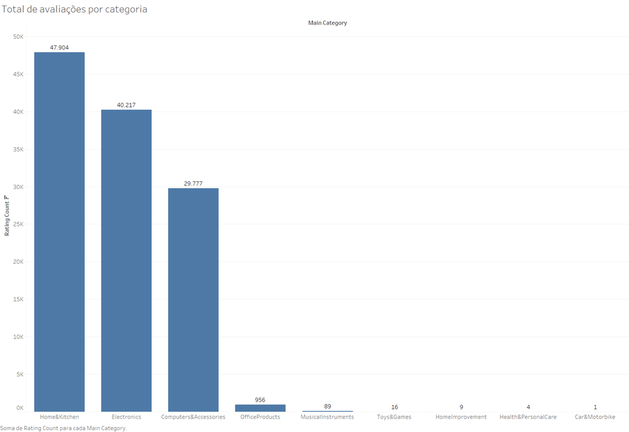

Total de avaliações por categoria

Para uma análise mais assertiva, serão avaliados apenas produtos que pertencem às categorias Home&Kitchen, Electronics e Computer&Accessories, que são as categorias com maior quantidade de avaliações, bem acima das demais categorias.

## Avaliação média por categoria

Agora será feita uma análise para verificar a avaliação média por categoria, entender quais são as categorias mais bem avaliadas e se há alguma em destaque.

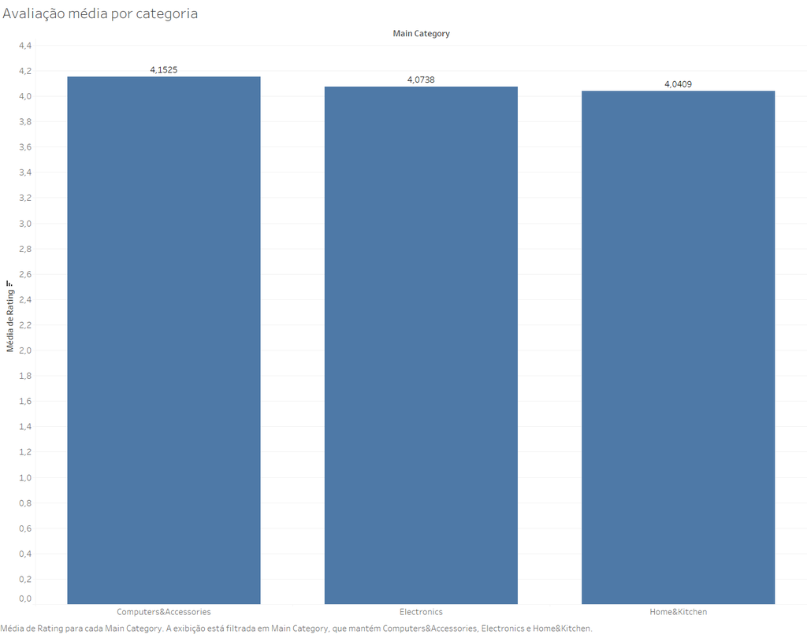

Avaliação média por categoria

As categorias têm avaliações médias bem próximas, com a categoria Computer&Accessories com a maior avaliação média.

## Desconto médio por categoria

Será feita uma análise para verificar o desconto médio por categoria, entender quais são as categorias com maior desconto e se há alguma em destaque.

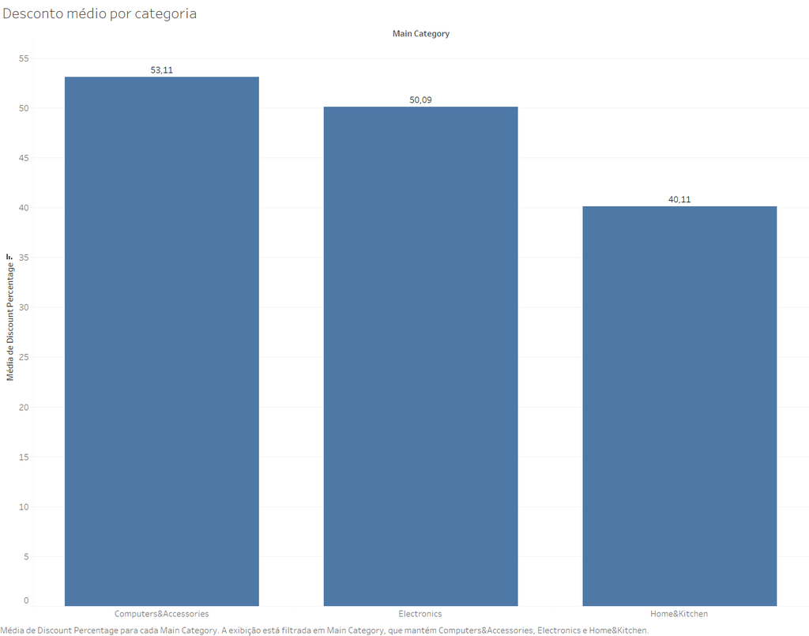

Desconto médio por categoria

Os produtos relacionados a Computer&Accessories têm o maior desconto percentual médio, com média bem acima da categoria Home&Kitchen e próxima da categoria Electronics.

## Desconto médio para Computer&Accessories

Uma vez selecionadas as 3 categorias que se destacaram nas análises anteriores, será feita uma análise mais detalhada para a categoria Computer&Accessories.

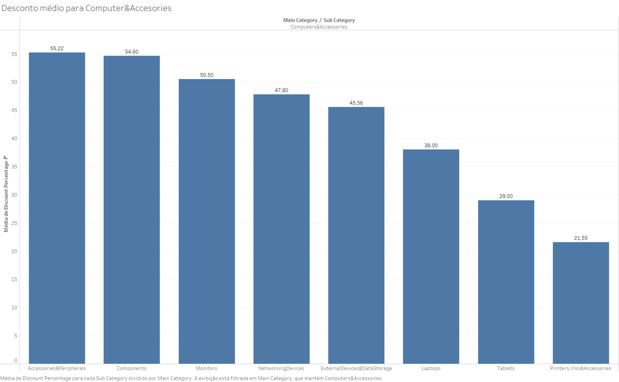

Desconto médio para Computer&Accessories

Há subcategorias com descontos percentuais médios bem acima de outras e em breve será feita uma relação com a quantidade de avaliações para entender se há relação entre desconto e quantidade de avaliações.

## Desconto médio para Electronics

Agora será feita uma análise mais detalhada para a categoria Electronics.

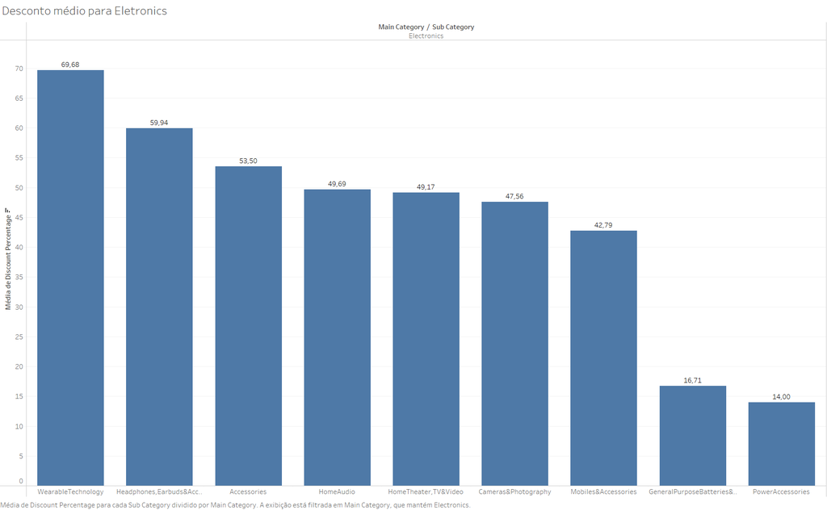

Desconto médio para Electronics

As subcategorias aqui seguem o mesmo padrão da categoria Computer&Accessories, com descontos percentuais médios bem acima de outras e será feita a mesma análise para entender a relação entre desconto e quantidade de avaliações.

## Desconto médio para Home&Kitchen

Por fim, será feita uma análise mais detalhada para a categoria Home&Kitchen.

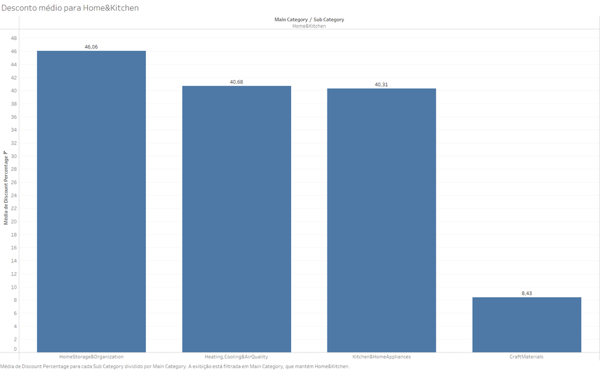

Desconto médio para Home&Kitchen

As subcategorias aqui têm descontos percentuais médios bem parecidos, exceto pela subcategoria CraftMaterials que tem um desconto percentual médio bem abaixo das demais.

## Quantidade de avaliações x Desconto para Electronics

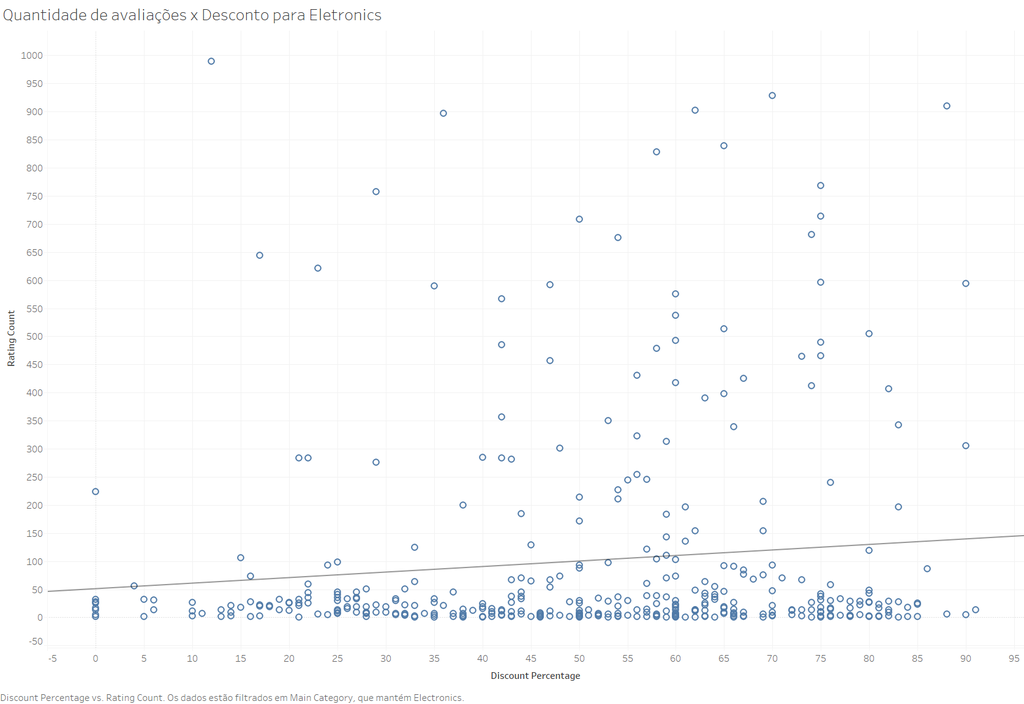

Quantidade de avaliações x Desconto para Electronics

Observando o gráfico, não é possível estabelecer uma relação clara entre as duas medidas, ainda que a linha de tendência seja inclinada positivamente.

## Quantidade de avaliações x Desconto para Computer&Accessories

Seguindo a mesma lógica, será feita uma análise para a categoria Computer&Accessories.

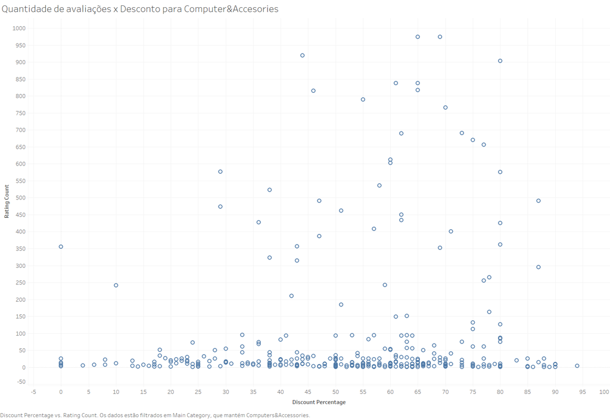

Quantidade de avaliações x Desconto para Computer&Accessories

## Quantidade de avaliações x Desconto para Home&Kitchen

Por fim, será feita uma análise para a categoria Home&Kitchen.

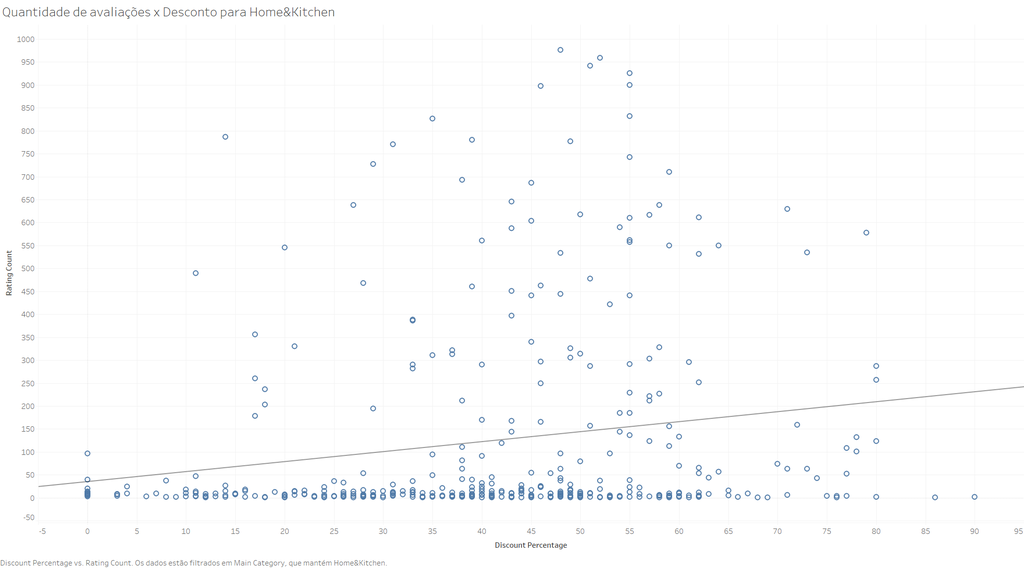

Quantidade de avaliações x Desconto para Home&Kitchen

Observando o gráfico, não é possível estabelecer uma relação clara entre as duas medidas, ainda que a linha de tendência seja inclinada positivamente.

## Quantidade de avaliações e Desconto médio para Computer&Accessories

Uma vez que o gráfico de dispersão não é suficiente para estabelecer uma relação clara entre as medidas, será feita uma análise mais detalhada para a categoria Computer&Accessories, com gráficos de barra para entender a relação entre a quantidade de avaliações e o desconto médio.

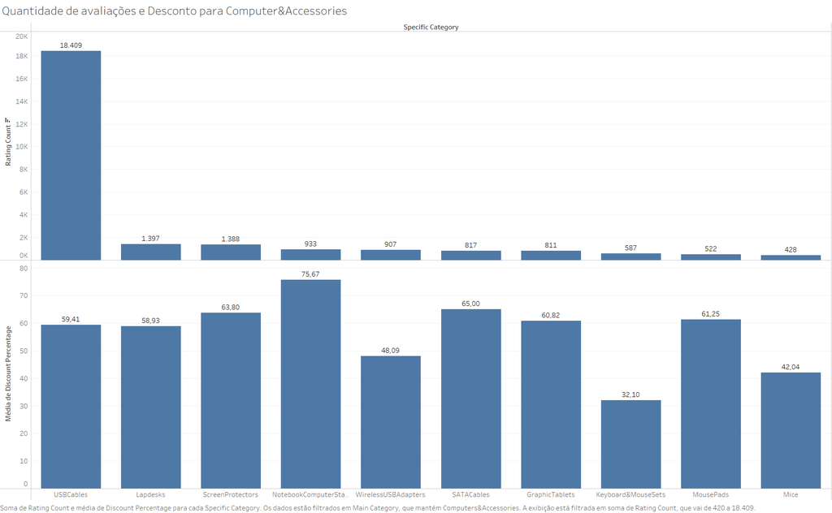

Quantidade de avaliações e Desconto médio para Computer&Accessories

A quantidade de USBCables vendida é muito grande e tende a serem preços baixos, por isso a análise irá focar nas outras subcategorias.

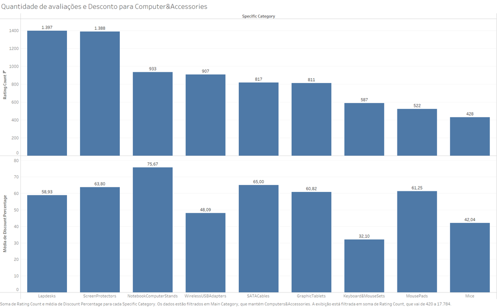

Quantidade de avaliações e Desconto médio para Computer&Accessories selecionado

As categorias específicas em geral têm descontos altos, exceto WirelessUSBAdapters, Keyboards&MouseSets e Mice, portanto o desconto para essas subcategorias pode ser reduzido, pois ao contrário das outras não depende tanto do desconto para serem muito vendidas

## Quantidade de avaliações e Desconto médio para Electronics

Uma vez que o gráfico de dispersão não é suficiente para estabelecer uma relação clara entre as medidas, será feita uma análise mais detalhada para a categoria Electronics, com gráficos de barra para entender a relação entre a quantidade de avaliações e o desconto médio.

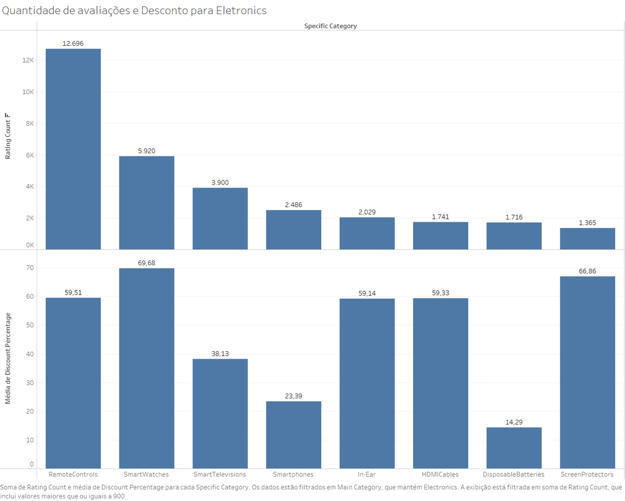

Quantidade de avaliações e Desconto médio para Electronics

Os descontos de SmartWatches, RemoteControls, In-Ear, HDMICables e ScreenProtectors são importantes para que essas categorias específicas sejam muito vendidas

Por outro lado, os descontos para SmartPhones, DisposableBatteries e SmartTelevisions são bem menores e ainda assim essas categorias específicas figuram nos mais vendidos

Uma estratégia para ter mais lucro pode ser reduzir o desconto de SmartPhones e DisposableBatteries, que já tem um alto número de vendas com desconto não tão alto.

## Quantidade de avaliações e Desconto médio para Home&Kitchen

Por fim, será feita uma análise mais detalhada para a categoria Home&Kitchen, com gráficos de barra para entender a relação entre a quantidade de avaliações e o desconto médio.

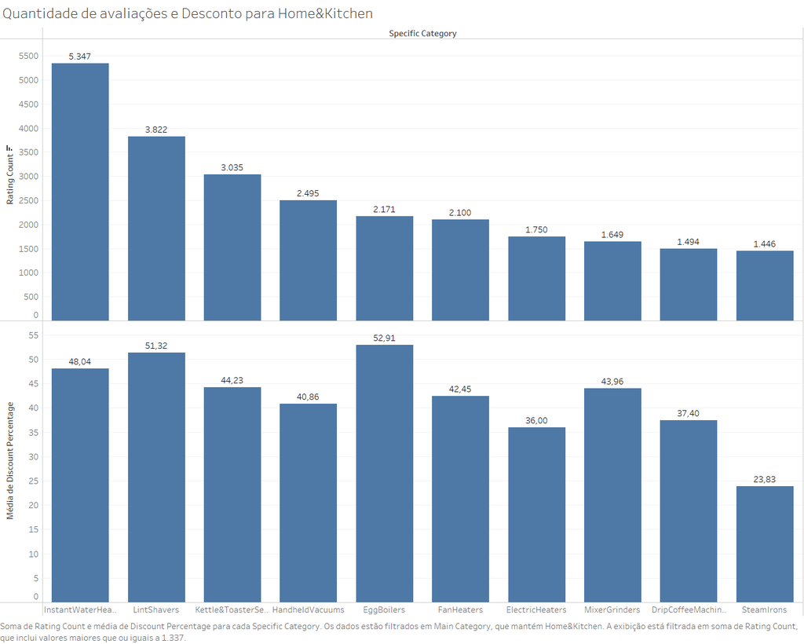

Quantidade de avaliações e Desconto médio para Home&Kitchen

Os valores de desconto são próximos para as categorias específicas de Home&Kitchen, apenas SteamIrons tem um valor menor, que poderia ser reduzido, já que mesmo baixo ainda figura entre os mais vendidos

# Recomendações

Para cada categoria será dada uma recomendação relacionada a descontos.

## Computer&Accessories

As categorias específicas em geral têm descontos altos, exceto WirelessUSBAdapters, Keyboards&MouseSets e Mice, portanto o desconto para elas pode ser reduzido, pois ao contrário das outras não depende tanto do desconto para serem muito vendidas.

## Electronics

Uma estratégia para ter mais lucro pode ser reduzir o desconto de SmartPhones e DisposableBatteries, que já tem um alto número de vendas com desconto não tão alto em relação a outras categorias específicas.

## Home&Kitchen

Os valores de desconto são próximos para as categorias específicas de Home&Kitchen, apenas SteamIrons tem um valor menor, que poderia ser reduzido, já que mesmo baixo ainda figura entre os mais vendidos em relação a outras categorias específicas.